# ANCOVA in TDE - Escrita (Acertos) (TDE - Escrita (Acertos))

Geiser C. Challco geiser@alumni.usp.br

- Descriptive Statistics of Initial Data
- ANCOVA and Pairwise for one factor: **grupo**
  - Without remove non-normal data
  - Computing ANCOVA and PairWise After removing non-normal data (OK)
    - Plots for ancova
    - Checking linearity assumption
    - Checking normality and homogeneity
- ANCOVA and Pairwise for two factors **grupo:Sexo**
  - Without remove non-normal data
  - Computing ANCOVA and PairWise After removing non-normal data (OK)
    - Plots for ancova
    - Checking linearity assumption
    - Checking normality and homogeneity
- ANCOVA and Pairwise for two factors **grupo:Zona**
  - Without remove non-normal data
  - Computing ANCOVA and PairWise After removing non-normal data (OK)
    - Plots for ancova
    - Checking linearity assumption
    - Checking normality and homogeneity
- ANCOVA and Pairwise for two factors **grupo:Cor.Raca**
  - Without remove non-normal data
  - Computing ANCOVA and PairWise After removing non-normal data (OK)
    - Plots for ancova
    - Checking linearity assumption
    - Checking normality and homogeneity
- ANCOVA and Pairwise for two factors **grupo:score.tde.quintile**
  - Without remove non-normal data
  - Computing ANCOVA and PairWise After removing non-normal data (OK)
    - Plots for ancova
    - Checking linearity assumption
    - Checking normality and homogeneity
- Summary of Results
  - Descriptive Statistics
  - ANCOVA Table Comparison
  - PairWise Table Comparison
  - EMMS Table Comparison

**NOTE**:

- Teste ANCOVA para determinar se houve diferenças significativas no TDE - Escrita (Acertos) (medido usando pre- e pos-testes).
- ANCOVA test to determine whether there were significant differences in TDE - Escrita (Acertos) (measured using pre- and post-tests).

# Descriptive Statistics of Initial Data

```r
df <- get.descriptives(dat, c(dv.pre, dv.pos), c("grupo"),
                       include.global = T, symmetry.test = T, normality.test = F)
df <- plyr::rbind.fill(
  df, do.call(plyr::rbind.fill, lapply(lfatores2, FUN = function(f) {
    if (nrow(dat) > 0 && sum(!is.na(unique(dat[[f]]))) > 1)
      get.descriptives(dat, c(dv.pre,dv.pos), c("grupo", f),
                       symmetry.test = T, normality.test = F)
    }))
)
```

[output not shown]

```r
(df <- df[,c(fatores1[fatores1 %in% colnames(df)],"variable",
             colnames(df)[!colnames(df) %in% c(fatores1,"variable")])])
```

```
##           grupo Sexo   Zona Cor.Raca score.tde.quintile      variable   n   mean median min max     sd    se
## 1      Controle <NA>   <NA>     <NA>               <NA> score.tde.pre 110 31.136   31.0  17  46  6.480 0.618
## 2  Experimental <NA>   <NA>     <NA>               <NA> score.tde.pre  46 30.022   29.0  19  46  7.154 1.055
## 3          <NA> <NA>   <NA>     <NA>               <NA> score.tde.pre 156 30.808   30.5  17  46  6.682 0.535
## 4      Controle <NA>   <NA>     <NA>               <NA> score.tde.pos 110 28.882   29.0   0  63 12.312 1.174
## 5  Experimental <NA>   <NA>     <NA>               <NA> score.tde.pos  46 26.565   26.0   1  50 11.968 1.765
## 6          <NA> <NA>   <NA>     <NA>               <NA> score.tde.pos 156 28.199   28.0   0  63 12.219 0.978
## 7      Controle    F   <NA>     <NA>               <NA> score.tde.pre  48 31.729   31.5  20  41  6.066 0.876
## 8      Controle    M   <NA>     <NA>               <NA> score.tde.pre  62 30.677   30.0  17  46  6.796 0.863
## 9  Experimental    F   <NA>     <NA>               <NA> score.tde.pre  18 31.111   32.0  20  40  6.115 1.441
## 10 Experimental    M   <NA>     <NA>               <NA> score.tde.pre  28 29.321   26.5  19  46  7.775 1.469
## 11     Controle    F   <NA>     <NA>               <NA> score.tde.pos  48 28.208   28.5   7  63 11.567 1.669
## 12     Controle    M   <NA>     <NA>               <NA> score.tde.pos  62 29.403   29.5   0  59 12.929 1.642
## 13 Experimental    F   <NA>     <NA>               <NA> score.tde.pos  18 27.111   26.5   1  44 10.471 2.468
## 14 Experimental    M   <NA>     <NA>               <NA> score.tde.pos  28 26.214   24.0   1  50 13.014 2.459
```

[output cut: 98 more lines]

| grupo | Sexo | Zona | Cor.Raca | score.tde.quintile | variable | n | mean | median | min | max | sd | se | ci | iqr | symmetry | skewness | kurtosis |
| --- | --- | --- | --- | --- | --- | --- | --- | --- | --- | --- | --- | --- | --- | --- | --- | --- | --- |
| Controle |  |  |  |  | score.tde.pre | 110 | 31.136 | 31.0 | 17 | 46 | 6.480 | 0.618 | 1.225 | 11.00 | YES | -0.110 | -1.000 |
| Experimental |  |  |  |  | score.tde.pre | 46 | 30.022 | 29.0 | 19 | 46 | 7.154 | 1.055 | 2.124 | 13.00 | YES | 0.228 | -1.195 |
|  |  |  |  |  | score.tde.pre | 156 | 30.808 | 30.5 | 17 | 46 | 6.682 | 0.535 | 1.057 | 12.00 | YES | -0.008 | -1.069 |
| Controle |  |  |  |  | score.tde.pos | 110 | 28.882 | 29.0 | 0 | 63 | 12.312 | 1.174 | 2.327 | 17.25 | YES | -0.062 | -0.184 |
| Experimental |  |  |  |  | score.tde.pos | 46 | 26.565 | 26.0 | 1 | 50 | 11.968 | 1.765 | 3.554 | 18.50 | YES | -0.069 | -0.438 |
|  |  |  |  |  | score.tde.pos | 156 | 28.199 | 28.0 | 0 | 63 | 12.219 | 0.978 | 1.933 | 16.50 | YES | -0.056 | -0.215 |
| Controle | F |  |  |  | score.tde.pre | 48 | 31.729 | 31.5 | 20 | 41 | 6.066 | 0.876 | 1.761 | 11.00 | YES | -0.307 | -1.140 |
| Controle | M |  |  |  | score.tde.pre | 62 | 30.677 | 30.0 | 17 | 46 | 6.796 | 0.863 | 1.726 | 11.00 | YES | 0.041 | -0.966 |
| Experimental | F |  |  |  | score.tde.pre | 18 | 31.111 | 32.0 | 20 | 40 | 6.115 | 1.441 | 3.041 | 9.25 | YES | -0.200 | -1.141 |
| Experimental | M |  |  |  | score.tde.pre | 28 | 29.321 | 26.5 | 19 | 46 | 7.775 | 1.469 | 3.015 | 14.25 | YES | 0.456 | -1.224 |
| Controle | F |  |  |  | score.tde.pos | 48 | 28.208 | 28.5 | 7 | 63 | 11.567 | 1.669 | 3.359 | 15.00 | YES | 0.292 | 0.183 |
| Controle | M |  |  |  | score.tde.pos | 62 | 29.403 | 29.5 | 0 | 59 | 12.929 | 1.642 | 3.283 | 18.75 | YES | -0.281 | -0.410 |
| Experimental | F |  |  |  | score.tde.pos | 18 | 27.111 | 26.5 | 1 | 44 | 10.471 | 2.468 | 5.207 | 11.25 | YES | -0.405 | 0.099 |
| Experimental | M |  |  |  | score.tde.pos | 28 | 26.214 | 24.0 | 1 | 50 | 13.014 | 2.459 | 5.046 | 19.25 | YES | 0.076 | -0.802 |
| Controle |  | Rural |  |  | score.tde.pre | 66 | 31.212 | 31.0 | 17 | 46 | 6.880 | 0.847 | 1.691 | 11.75 | YES | -0.061 | -1.044 |
| Controle |  | Urbana |  |  | score.tde.pre | 11 | 29.000 | 28.0 | 22 | 39 | 4.940 | 1.489 | 3.318 | 6.00 | NO | 0.561 | -0.801 |
| Controle |  |  |  |  | score.tde.pre | 33 | 31.697 | 33.0 | 20 | 39 | 6.111 | 1.064 | 2.167 | 9.00 | YES | -0.498 | -1.042 |
| Experimental |  | Rural |  |  | score.tde.pre | 31 | 29.645 | 28.0 | 19 | 46 | 7.579 | 1.361 | 2.780 | 13.50 | YES | 0.333 | -1.194 |
| Experimental |  | Urbana |  |  | score.tde.pre | 5 | 29.200 | 30.0 | 21 | 38 | 6.834 | 3.056 | 8.485 | 9.00 | YES | 0.028 | -1.949 |
| Experimental |  |  |  |  | score.tde.pre | 10 | 31.600 | 30.5 | 22 | 40 | 6.328 | 2.001 | 4.527 | 9.75 | YES | -0.008 | -1.707 |
| Controle |  | Rural |  |  | score.tde.pos | 66 | 28.015 | 27.5 | 0 | 50 | 11.830 | 1.456 | 2.908 | 14.00 | YES | -0.282 | -0.306 |
| Controle |  | Urbana |  |  | score.tde.pos | 11 | 28.364 | 29.0 | 8 | 42 | 9.973 | 3.007 | 6.700 | 11.50 | NO | -0.526 | -0.778 |
| Controle |  |  |  |  | score.tde.pos | 33 | 30.788 | 30.0 | 7 | 63 | 13.986 | 2.435 | 4.959 | 20.00 | YES | 0.145 | -0.628 |
| Experimental |  | Rural |  |  | score.tde.pos | 31 | 28.065 | 26.0 | 11 | 50 | 11.144 | 2.002 | 4.088 | 19.50 | NO | 0.519 | -1.025 |
| Experimental |  | Urbana |  |  | score.tde.pos | 5 | 22.600 | 25.0 | 2 | 36 | 13.409 | 5.997 | 16.649 | 14.00 | YES | -0.464 | -1.635 |
| Experimental |  |  |  |  | score.tde.pos | 10 | 23.900 | 27.0 | 1 | 38 | 14.067 | 4.448 | 10.063 | 17.75 | NO | -0.562 | -1.295 |
| Controle |  |  | Branca |  | score.tde.pre | 11 | 33.000 | 31.0 | 20 | 46 | 7.861 | 2.370 | 5.281 | 9.50 | YES | 0.217 | -1.174 |
| Controle |  |  | Indígena |  | score.tde.pre | 2 | 37.500 | 37.5 | 34 | 41 | 4.950 | 3.500 | 44.472 | 3.50 | few data | 0.000 | 0.000 |
| Controle |  |  | Parda |  | score.tde.pre | 50 | 31.060 | 31.0 | 17 | 42 | 6.412 | 0.907 | 1.822 | 11.00 | YES | -0.237 | -1.195 |
| Controle |  |  | Preta |  | score.tde.pre | 1 | 26.000 | 26.0 | 26 | 26 |  |  |  | 0.00 | few data | 0.000 | 0.000 |
| Controle |  |  |  |  | score.tde.pre | 46 | 30.609 | 30.5 | 20 | 39 | 6.256 | 0.922 | 1.858 | 11.00 | YES | -0.216 | -1.329 |
| Experimental |  |  | Branca |  | score.tde.pre | 5 | 35.200 | 37.0 | 21 | 46 | 9.094 | 4.067 | 11.292 | 4.00 | YES | -0.420 | -1.411 |
| Experimental |  |  | Indígena |  | score.tde.pre | 8 | 30.000 | 27.0 | 21 | 42 | 8.401 | 2.970 | 7.023 | 14.25 | YES | 0.325 | -1.861 |
| Experimental |  |  | Parda |  | score.tde.pre | 17 | 26.647 | 25.0 | 19 | 40 | 6.103 | 1.480 | 3.138 | 8.00 | NO | 0.642 | -0.724 |
| Experimental |  |  |  |  | score.tde.pre | 16 | 32.000 | 33.0 | 23 | 40 | 5.727 | 1.432 | 3.052 | 10.50 | YES | -0.252 | -1.555 |
| Controle |  |  | Branca |  | score.tde.pos | 11 | 36.000 | 36.0 | 16 | 63 | 11.533 | 3.477 | 7.748 | 8.50 | NO | 0.687 | 0.593 |
| Controle |  |  | Indígena |  | score.tde.pos | 2 | 26.500 | 26.5 | 25 | 28 | 2.121 | 1.500 | 19.059 | 1.50 | few data | 0.000 | 0.000 |
| Controle |  |  | Parda |  | score.tde.pos | 50 | 25.920 | 25.5 | 0 | 50 | 12.128 | 1.715 | 3.447 | 12.75 | YES | -0.070 | -0.296 |
| Controle |  |  | Preta |  | score.tde.pos | 1 | 40.000 | 40.0 | 40 | 40 |  |  |  | 0.00 | few data | 0.000 | 0.000 |
| Controle |  |  |  |  | score.tde.pos | 46 | 30.261 | 32.0 | 5 | 59 | 12.259 | 1.808 | 3.641 | 20.00 | YES | -0.171 | -0.824 |
| Experimental |  |  | Branca |  | score.tde.pos | 5 | 33.800 | 37.0 | 2 | 50 | 18.660 | 8.345 | 23.170 | 8.00 | NO | -0.825 | -1.181 |
| Experimental |  |  | Indígena |  | score.tde.pos | 8 | 29.250 | 26.5 | 15 | 50 | 11.877 | 4.199 | 9.930 | 14.00 | YES | 0.495 | -1.321 |
| Experimental |  |  | Parda |  | score.tde.pos | 17 | 24.059 | 22.0 | 1 | 43 | 10.503 | 2.547 | 5.400 | 11.00 | YES | 0.052 | -0.302 |
| Experimental |  |  |  |  | score.tde.pos | 16 | 25.625 | 26.0 | 1 | 44 | 11.135 | 2.784 | 5.933 | 14.50 | YES | -0.349 | -0.545 |
| Controle |  |  |  | 1st quintile | score.tde.pre | 1 | 17.000 | 17.0 | 17 | 17 |  |  |  | 0.00 | few data | 0.000 | 0.000 |
| Controle |  |  |  | 2nd quintile | score.tde.pre | 58 | 26.121 | 26.0 | 20 | 31 | 3.559 | 0.467 | 0.936 | 6.50 | YES | -0.221 | -1.231 |
| Controle |  |  |  | 3rd quintile | score.tde.pre | 49 | 36.796 | 37.0 | 32 | 42 | 2.236 | 0.319 | 0.642 | 4.00 | YES | -0.111 | -0.550 |
| Controle |  |  |  | 4th quintile | score.tde.pre | 2 | 45.000 | 45.0 | 44 | 46 | 1.414 | 1.000 | 12.706 | 1.00 | few data | 0.000 | 0.000 |
| Experimental |  |  |  | 2nd quintile | score.tde.pre | 25 | 24.280 | 24.0 | 19 | 30 | 3.156 | 0.631 | 1.303 | 5.00 | YES | 0.218 | -1.240 |
| Experimental |  |  |  | 3rd quintile | score.tde.pre | 20 | 36.400 | 37.0 | 32 | 42 | 2.998 | 0.670 | 1.403 | 4.50 | YES | -0.023 | -1.163 |
| Experimental |  |  |  | 4th quintile | score.tde.pre | 1 | 46.000 | 46.0 | 46 | 46 |  |  |  | 0.00 | few data | 0.000 | 0.000 |
| Controle |  |  |  | 1st quintile | score.tde.pos | 1 | 24.000 | 24.0 | 24 | 24 |  |  |  | 0.00 | few data | 0.000 | 0.000 |
| Controle |  |  |  | 2nd quintile | score.tde.pos | 58 | 24.310 | 24.0 | 0 | 48 | 11.494 | 1.509 | 3.022 | 15.75 | YES | -0.121 | -0.703 |
| Controle |  |  |  | 3rd quintile | score.tde.pos | 49 | 33.939 | 34.0 | 5 | 63 | 11.401 | 1.629 | 3.275 | 15.00 | YES | 0.034 | 0.074 |
| Controle |  |  |  | 4th quintile | score.tde.pos | 2 | 40.000 | 40.0 | 37 | 43 | 4.243 | 3.000 | 38.119 | 3.00 | few data | 0.000 | 0.000 |
| Experimental |  |  |  | 2nd quintile | score.tde.pos | 25 | 21.320 | 19.0 | 1 | 43 | 9.577 | 1.915 | 3.953 | 9.00 | YES | 0.114 | 0.315 |
| Experimental |  |  |  | 3rd quintile | score.tde.pos | 20 | 31.950 | 34.0 | 1 | 50 | 11.302 | 2.527 | 5.289 | 11.75 | NO | -0.862 | 0.633 |
| Experimental |  |  |  | 4th quintile | score.tde.pos | 1 | 50.000 | 50.0 | 50 | 50 |  |  |  | 0.00 | few data | 0.000 | 0.000 |

# ANCOVA and Pairwise for one factor: **grupo**

## Without remove non-normal data

```r
pdat = remove_group_data(dat[!is.na(dat[["grupo"]]),], "score.tde.pos", "grupo")

pdat.long <- rbind(pdat[,c("id","grupo")], pdat[,c("id","grupo")])
pdat.long[["time"]] <- c(rep("pre", nrow(pdat)), rep("pos", nrow(pdat)))
pdat.long[["time"]] <- factor(pdat.long[["time"]], c("pre","pos"))
pdat.long[["score.tde"]] <- c(pdat[["score.tde.pre"]], pdat[["score.tde.pos"]])

aov = anova_test(pdat, score.tde.pos ~ score.tde.pre + grupo)
laov[["grupo"]] <- get_anova_table(aov)
```

```r
pwc <- emmeans_test(pdat, score.tde.pos ~ grupo, covariate = score.tde.pre,
                    p.adjust.method = "bonferroni")
```

```r
pwc.long <- emmeans_test(dplyr::group_by_at(pdat.long, "grupo"),
                          score.tde ~ time,
                          p.adjust.method = "bonferroni")
lpwc[["grupo"]] <- plyr::rbind.fill(pwc, pwc.long)
```

```r
ds <- get.descriptives(pdat, "score.tde.pos", "grupo", covar = "score.tde.pre")
ds <- merge(ds[ds$variable != "score.tde.pre",],
            ds[ds$variable == "score.tde.pre", !colnames(ds) %in% c("variable")],
            by = "grupo", all.x = T, suffixes = c("", ".score.tde.pre"))
ds <- merge(get_emmeans(pwc), ds, by = "grupo", suffixes = c(".emms", ""))
ds <- ds[,c("grupo","n","mean.score.tde.pre","se.score.tde.pre","mean","se","emmean","se.emms")]

colnames(ds) <- c("grupo", "N", paste0(c("M","SE")," (pre)"),
                  paste0(c("M","SE"), " (unadj)"), paste0(c("M", "SE"), " (adj)"))

lemms[["grupo"]] <- ds
```

## Computing ANCOVA and PairWise After removing non-normal data (OK)

```r
wdat = pdat

res = residuals(lm(score.tde.pos ~ score.tde.pre + grupo, data = wdat))
non.normal = getNonNormal(res, wdat$id, plimit = 0.05)

wdat = wdat[!wdat$id %in% non.normal,]

wdat.long <- rbind(wdat[,c("id","grupo")], wdat[,c("id","grupo")])
wdat.long[["time"]] <- c(rep("pre", nrow(wdat)), rep("pos", nrow(wdat)))
wdat.long[["time"]] <- factor(wdat.long[["time"]], c("pre","pos"))
wdat.long[["score.tde"]] <- c(wdat[["score.tde.pre"]], wdat[["score.tde.pos"]])

ldat[["grupo"]] = wdat

(non.normal)
```

```r
aov = anova_test(wdat, score.tde.pos ~ score.tde.pre + grupo)
laov[["grupo"]] <- merge(get_anova_table(aov), laov[["grupo"]], by="Effect", suffixes = c("","'"))

(df = get_anova_table(aov))
```

```
## ANOVA Table (type II tests)
##
##          Effect DFn DFd      F        p p<.05   ges
## 1 score.tde.pre   1 153 45.279 3.22e-10     * 0.228
## 2         grupo   1 153  0.502 4.80e-01       0.003
```

| Effect | DFn | DFd | F | p | p<.05 | ges |
| --- | --- | --- | --- | --- | --- | --- |
| score.tde.pre | 1 | 153 | 45.279 | 0.00 | * | 0.228 |
| grupo | 1 | 153 | 0.502 | 0.48 |  | 0.003 |

| term | .y. | group1 | group2 | df | statistic | p | p.adj | p.adj.signif |
| --- | --- | --- | --- | --- | --- | --- | --- | --- |
| score.tde.pre*grupo | score.tde.pos | Controle | Experimental | 153 | 0.709 | 0.48 | 0.48 | ns |

```r
pwc.long <- emmeans_test(dplyr::group_by_at(wdat.long, "grupo"),
                         score.tde ~ time,
                         p.adjust.method = "bonferroni")
lpwc[["grupo"]] <- merge(plyr::rbind.fill(pwc, pwc.long), lpwc[["grupo"]], by=c("grupo","term",".y.","group1","group2"), suffixes = c("","'"))
```

| grupo | term | .y. | group1 | group2 | df | statistic | p | p.adj | p.adj.signif |
| --- | --- | --- | --- | --- | --- | --- | --- | --- | --- |
| Controle | time | score.tde | pre | pos | 308 | 1.698 | 0.090 | 0.090 | ns |
| Experimental | time | score.tde | pre | pos | 308 | 1.684 | 0.093 | 0.093 | ns |

```r
ds <- get.descriptives(wdat, "score.tde.pos", "grupo", covar = "score.tde.pre")
ds <- merge(ds[ds$variable != "score.tde.pre",],
            ds[ds$variable == "score.tde.pre", !colnames(ds) %in% c("variable")],
            by = "grupo", all.x = T, suffixes = c("", ".score.tde.pre"))
ds <- merge(get_emmeans(pwc), ds, by = "grupo", suffixes = c(".emms", ""))
ds <- ds[,c("grupo","n","mean.score.tde.pre","se.score.tde.pre","mean","se","emmean","se.emms")]

colnames(ds) <- c("grupo", "N", paste0(c("M","SE")," (pre)"),
                  paste0(c("M","SE"), " (unadj)"), paste0(c("M", "SE"), " (adj)"))

lemms[["grupo"]] <- merge(ds, lemms[["grupo"]], by=c("grupo"), suffixes = c("","'"))
```

| grupo | N | M (pre) | SE (pre) | M (unadj) | SE (unadj) | M (adj) | SE (adj) |
| --- | --- | --- | --- | --- | --- | --- | --- |
| Controle | 110 | 31.136 | 0.618 | 28.882 | 1.174 | 28.595 | 1.027 |
| Experimental | 46 | 30.022 | 1.055 | 26.565 | 1.765 | 27.251 | 1.590 |

### Plots for ancova

```r
plots <- oneWayAncovaPlots(
  wdat, "score.tde.pos", "grupo", aov, list("grupo"=pwc), addParam = c("mean_se"),
  font.label.size=10, step.increase=0.05, p.label="p.adj",
  subtitle = which(aov$Effect == "grupo"))
```

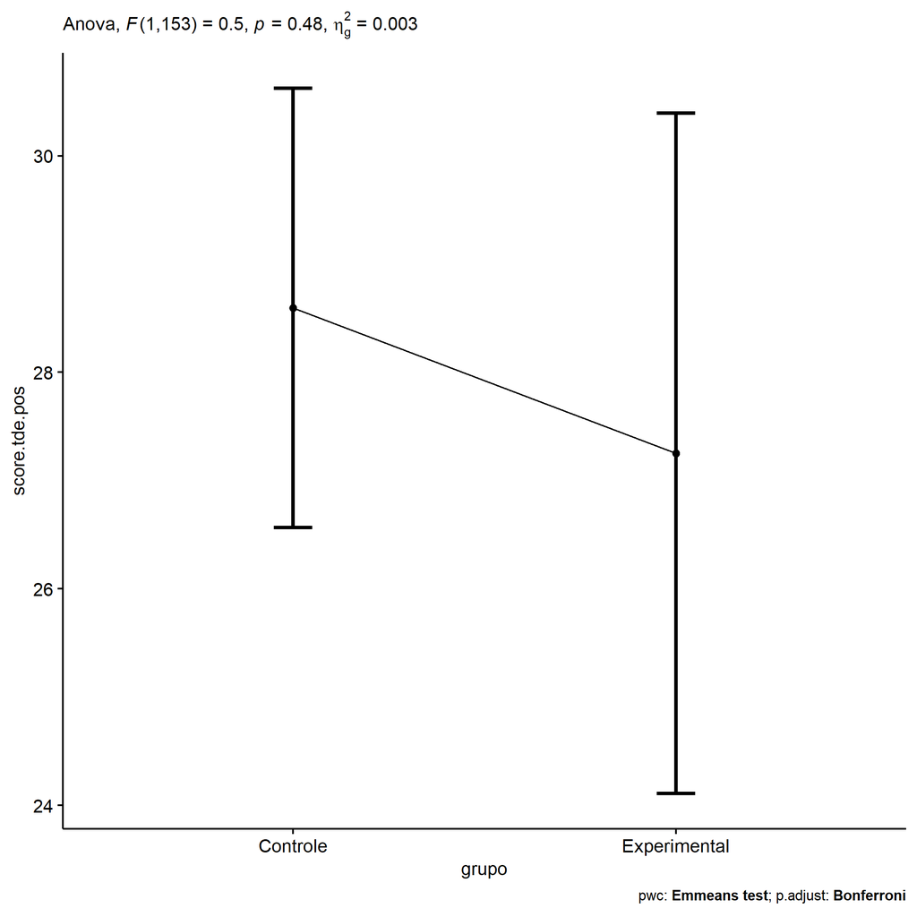

```r
if (!is.null(nrow(plots[["grupo"]]$data)))
  plots[["grupo"]] + ggplot2::scale_color_manual(values = color[["grupo"]])
```

```r
plots <- oneWayAncovaBoxPlots(
  wdat, "score.tde.pos", "grupo", aov, pwc, covar = "score.tde.pre",
  theme = "classic", color = color[["grupo"]],
  subtitle = which(aov$Effect == "grupo"))
```

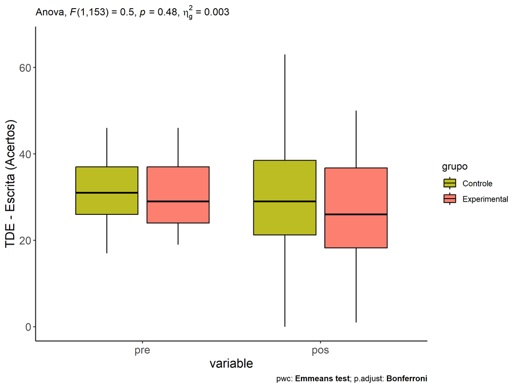

```r
if (length(unique(wdat[["grupo"]])) > 1)
  plots[["grupo"]] + ggplot2::ylab("TDE - Escrita (Acertos)") + ggplot2::scale_x_discrete(labels=c('pre', 'pos'))
```

```r
if (length(unique(wdat.long[["grupo"]])) > 1)
  plots <- oneWayAncovaBoxPlots(
    wdat.long, "score.tde", "grupo", aov, pwc.long, pre.post = "time",
    theme = "classic", color = color$prepost)
```

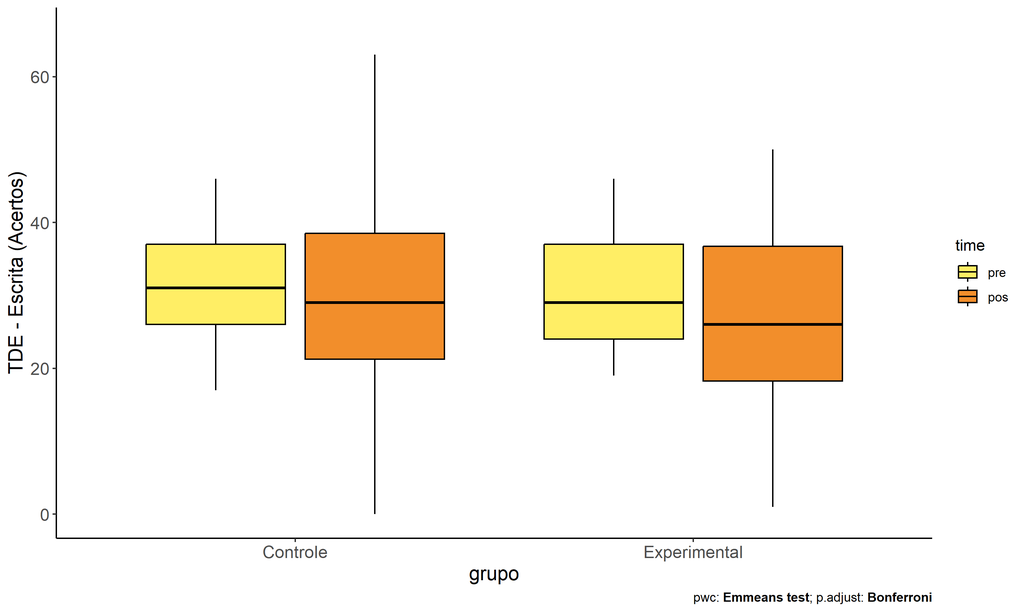

```r
if (length(unique(wdat.long[["grupo"]])) > 1)
  plots[["grupo"]] + ggplot2::ylab("TDE - Escrita (Acertos)")
```

### Checking linearity assumption

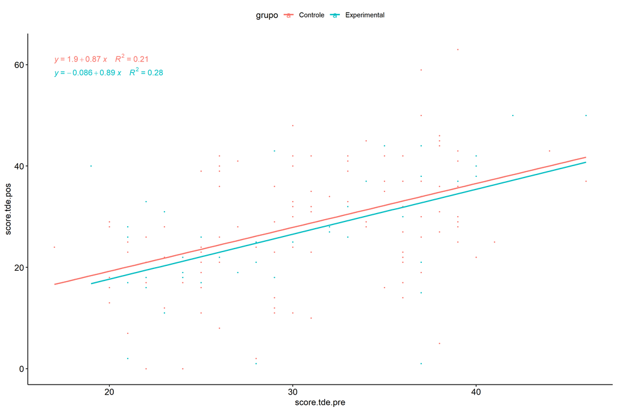

```r
ggscatter(wdat, x = "score.tde.pre", y = "score.tde.pos", size = 0.5,
          color = "grupo", add = "reg.line")+
  stat_regline_equation(
    aes(label =  paste(..eq.label.., ..rr.label.., sep = "~~~~"), color = grupo)
  )
```

### Checking normality and homogeneity

```r
res <- augment(lm(score.tde.pos ~ score.tde.pre + grupo, data = wdat))
```

```r
shapiro_test(res$.resid)
```

```
## # A tibble: 1 × 3
##   variable   statistic p.value
##   <chr>          <dbl>   <dbl>
## 1 res$.resid     0.990   0.363
```

```r
levene_test(res, .resid ~ grupo)
```

```
## # A tibble: 1 × 4
##     df1   df2 statistic     p
##   <int> <int>     <dbl> <dbl>
## 1     1   154      1.76 0.186
```

# ANCOVA and Pairwise for two factors **grupo:Sexo**

## Without remove non-normal data

```r
pdat = remove_group_data(dat[!is.na(dat[["grupo"]]) & !is.na(dat[["Sexo"]]),], "score.tde.pos", c("grupo","Sexo"))

pdat.long <- rbind(pdat[,c("id","grupo","Sexo")], pdat[,c("id","grupo","Sexo")])
pdat.long[["time"]] <- c(rep("pre", nrow(pdat)), rep("pos", nrow(pdat)))
pdat.long[["time"]] <- factor(pdat.long[["time"]], c("pre","pos"))
pdat.long[["score.tde"]] <- c(pdat[["score.tde.pre"]], pdat[["score.tde.pos"]])

aov = anova_test(pdat, score.tde.pos ~ score.tde.pre + grupo*Sexo)
laov[["grupo:Sexo"]] <- get_anova_table(aov)
```

```r
pwcs <- list()
pwcs[["Sexo"]] <- emmeans_test(
  group_by(pdat, grupo), score.tde.pos ~ Sexo,
  covariate = score.tde.pre, p.adjust.method = "bonferroni")
pwcs[["grupo"]] <- emmeans_test(
  group_by(pdat, Sexo), score.tde.pos ~ grupo,
  covariate = score.tde.pre, p.adjust.method = "bonferroni")

pwc <- plyr::rbind.fill(pwcs[["grupo"]], pwcs[["Sexo"]])
pwc <- pwc[,c("grupo","Sexo", colnames(pwc)[!colnames(pwc) %in% c("grupo","Sexo")])]
```

```r
pwc.long <- emmeans_test(dplyr::group_by_at(pdat.long, c("grupo","Sexo")),
                         score.tde ~ time,
                         p.adjust.method = "bonferroni")
lpwc[["grupo:Sexo"]] <- plyr::rbind.fill(pwc, pwc.long)
```

```r
ds <- get.descriptives(pdat, "score.tde.pos", c("grupo","Sexo"), covar = "score.tde.pre")
ds <- merge(ds[ds$variable != "score.tde.pre",],
            ds[ds$variable == "score.tde.pre", !colnames(ds) %in% c("variable")],
            by = c("grupo","Sexo"), all.x = T, suffixes = c("", ".score.tde.pre"))
ds <- merge(get_emmeans(pwcs[["grupo"]]), ds, by = c("grupo","Sexo"), suffixes = c(".emms", ""))
ds <- ds[,c("grupo","Sexo","n","mean.score.tde.pre","se.score.tde.pre","mean","se","emmean","se.emms")]

colnames(ds) <- c("grupo","Sexo", "N", paste0(c("M","SE")," (pre)"),
                  paste0(c("M","SE"), " (unadj)"), paste0(c("M", "SE"), " (adj)"))

lemms[["grupo:Sexo"]] <- ds
```

## Computing ANCOVA and PairWise After removing non-normal data (OK)

```r
wdat = pdat

res = residuals(lm(score.tde.pos ~ score.tde.pre + grupo*Sexo, data = wdat))
non.normal = getNonNormal(res, wdat$id, plimit = 0.05)

wdat = wdat[!wdat$id %in% non.normal,]

wdat.long <- rbind(wdat[,c("id","grupo","Sexo")], wdat[,c("id","grupo","Sexo")])
wdat.long[["time"]] <- c(rep("pre", nrow(wdat)), rep("pos", nrow(wdat)))
wdat.long[["time"]] <- factor(wdat.long[["time"]], c("pre","pos"))
wdat.long[["score.tde"]] <- c(wdat[["score.tde.pre"]], wdat[["score.tde.pos"]])


ldat[["grupo:Sexo"]] = wdat

(non.normal)
```

```r
aov = anova_test(wdat, score.tde.pos ~ score.tde.pre + grupo*Sexo)
laov[["grupo:Sexo"]] <- merge(get_anova_table(aov), laov[["grupo:Sexo"]], by="Effect", suffixes = c("","'"))

(df = get_anova_table(aov))
```

```
## ANOVA Table (type II tests)
##
##          Effect DFn DFd      F        p p<.05      ges
## 1 score.tde.pre   1 151 45.687 2.83e-10     * 0.232000
## 2         grupo   1 151  0.547 4.61e-01       0.004000
## 3          Sexo   1 151  0.947 3.32e-01       0.006000
## 4    grupo:Sexo   1 151  0.139 7.10e-01       0.000917
```

| Effect | DFn | DFd | F | p | p<.05 | ges |
| --- | --- | --- | --- | --- | --- | --- |
| score.tde.pre | 1 | 151 | 45.687 | 0.000 | * | 0.232 |
| grupo | 1 | 151 | 0.547 | 0.461 |  | 0.004 |
| Sexo | 1 | 151 | 0.947 | 0.332 |  | 0.006 |
| grupo:Sexo | 1 | 151 | 0.139 | 0.710 |  | 0.001 |

```r
pwcs <- list()
pwcs[["Sexo"]] <- emmeans_test(
  group_by(wdat, grupo), score.tde.pos ~ Sexo,
  covariate = score.tde.pre, p.adjust.method = "bonferroni")
pwcs[["grupo"]] <- emmeans_test(
  group_by(wdat, Sexo), score.tde.pos ~ grupo,
  covariate = score.tde.pre, p.adjust.method = "bonferroni")

pwc <- plyr::rbind.fill(pwcs[["grupo"]], pwcs[["Sexo"]])
pwc <- pwc[,c("grupo","Sexo", colnames(pwc)[!colnames(pwc) %in% c("grupo","Sexo")])]
```

| grupo | Sexo | term | .y. | group1 | group2 | df | statistic | p | p.adj | p.adj.signif |
| --- | --- | --- | --- | --- | --- | --- | --- | --- | --- | --- |
|  | F | score.tde.pre*grupo | score.tde.pos | Controle | Experimental | 151 | 0.185 | 0.854 | 0.854 | ns |
|  | M | score.tde.pre*grupo | score.tde.pos | Controle | Experimental | 151 | 0.808 | 0.421 | 0.421 | ns |
| Controle |  | score.tde.pre*Sexo | score.tde.pos | F | M | 151 | -1.021 | 0.309 | 0.309 | ns |
| Experimental |  | score.tde.pre*Sexo | score.tde.pos | F | M | 151 | -0.210 | 0.834 | 0.834 | ns |

```r
pwc.long <- emmeans_test(dplyr::group_by_at(wdat.long, c("grupo","Sexo")),
                         score.tde ~ time,
                         p.adjust.method = "bonferroni")
lpwc[["grupo:Sexo"]] <- merge(plyr::rbind.fill(pwc, pwc.long), lpwc[["grupo:Sexo"]], by=c("grupo","Sexo","term",".y.","group1","group2"), suffixes = c("","'"))
```

| grupo | Sexo | term | .y. | group1 | group2 | df | statistic | p | p.adj | p.adj.signif |
| --- | --- | --- | --- | --- | --- | --- | --- | --- | --- | --- |
| Controle | F | time | score.tde | pre | pos | 304 | 1.744 | 0.082 | 0.082 | ns |
| Controle | M | time | score.tde | pre | pos | 304 | 0.717 | 0.474 | 0.474 | ns |
| Experimental | F | time | score.tde | pre | pos | 304 | 1.213 | 0.226 | 0.226 | ns |
| Experimental | M | time | score.tde | pre | pos | 304 | 1.175 | 0.241 | 0.241 | ns |

```r
ds <- get.descriptives(wdat, "score.tde.pos", c("grupo","Sexo"), covar = "score.tde.pre")
ds <- merge(ds[ds$variable != "score.tde.pre",],
            ds[ds$variable == "score.tde.pre", !colnames(ds) %in% c("variable")],
            by = c("grupo","Sexo"), all.x = T, suffixes = c("", ".score.tde.pre"))
ds <- merge(get_emmeans(pwcs[["grupo"]]), ds, by = c("grupo","Sexo"), suffixes = c(".emms", ""))
ds <- ds[,c("grupo","Sexo","n","mean.score.tde.pre","se.score.tde.pre","mean","se","emmean","se.emms")]

colnames(ds) <- c("grupo","Sexo", "N", paste0(c("M","SE")," (pre)"),
                  paste0(c("M","SE"), " (unadj)"), paste0(c("M", "SE"), " (adj)"))

lemms[["grupo:Sexo"]] <- merge(ds, lemms[["grupo:Sexo"]], by=c("grupo","Sexo"), suffixes = c("","'"))
```

| grupo | Sexo | N | M (pre) | SE (pre) | M (unadj) | SE (unadj) | M (adj) | SE (adj) |
| --- | --- | --- | --- | --- | --- | --- | --- | --- |
| Controle | F | 48 | 31.729 | 0.876 | 28.208 | 1.669 | 27.394 | 1.563 |
| Controle | M | 62 | 30.677 | 0.863 | 29.403 | 1.642 | 29.518 | 1.371 |
| Experimental | F | 18 | 31.111 | 1.441 | 27.111 | 2.468 | 26.843 | 2.545 |
| Experimental | M | 28 | 29.321 | 1.469 | 26.214 | 2.459 | 27.528 | 2.049 |

### Plots for ancova

```r
plots <- twoWayAncovaPlots(
  wdat, "score.tde.pos", c("grupo","Sexo"), aov, pwcs, addParam = c("mean_se"),
  font.label.size=10, step.increase=0.05, p.label="p.adj",
  subtitle = which(aov$Effect == "grupo:Sexo"))
```

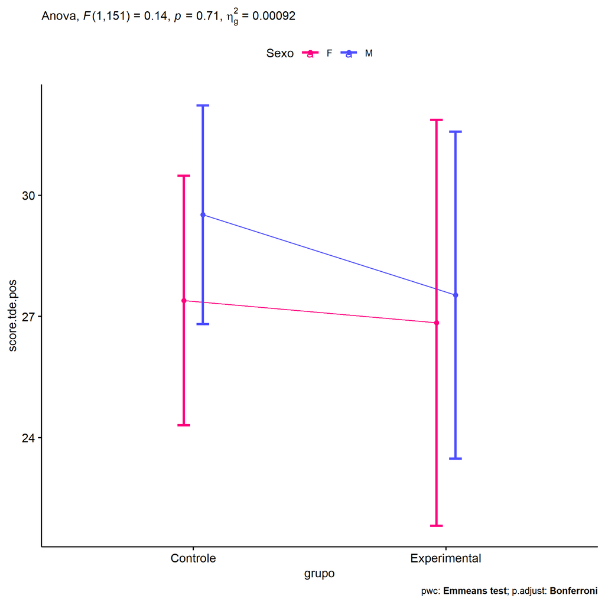

```r
if (!is.null(plots[["grupo"]]))
  plots[["grupo"]] + ggplot2::scale_color_manual(values = color[["Sexo"]])
```

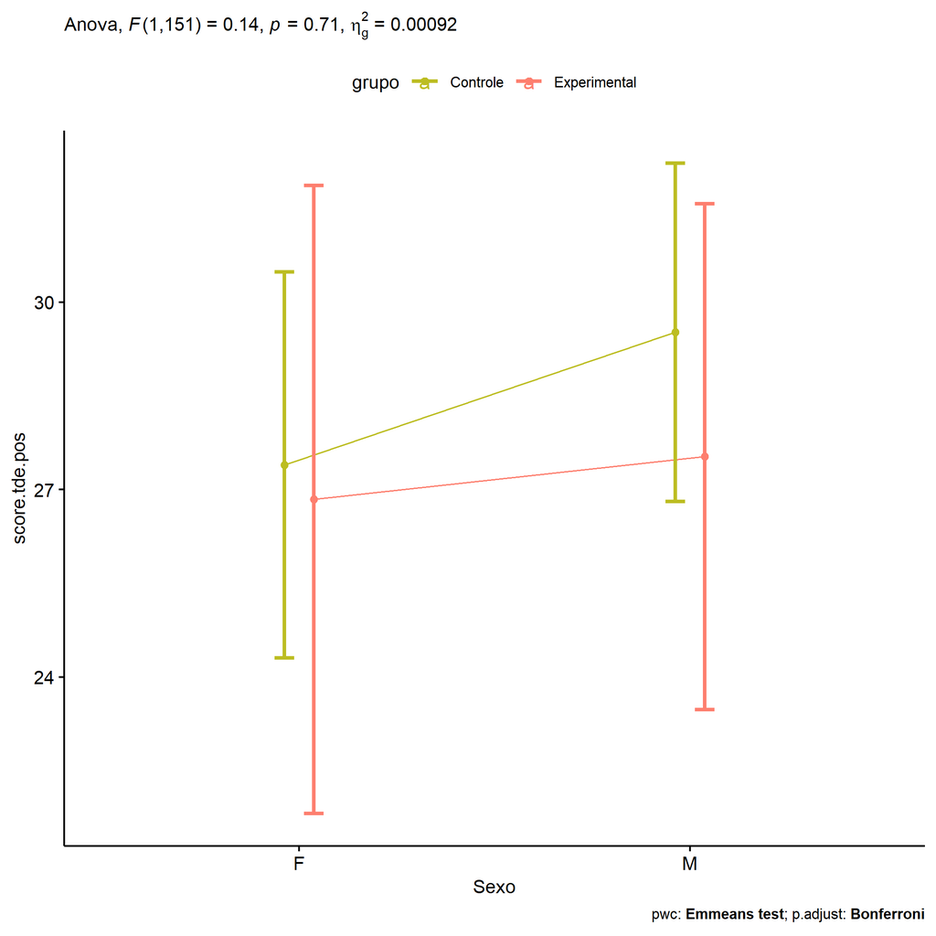

```r
if (!is.null(plots[["Sexo"]]))
  plots[["Sexo"]] + ggplot2::scale_color_manual(values = color[["grupo"]])
```

```r
plots <- twoWayAncovaBoxPlots(
  wdat, "score.tde.pos", c("grupo","Sexo"), aov, pwcs, covar = "score.tde.pre",
  theme = "classic", color = color[["grupo:Sexo"]],
  subtitle = which(aov$Effect == "grupo:Sexo"))
```

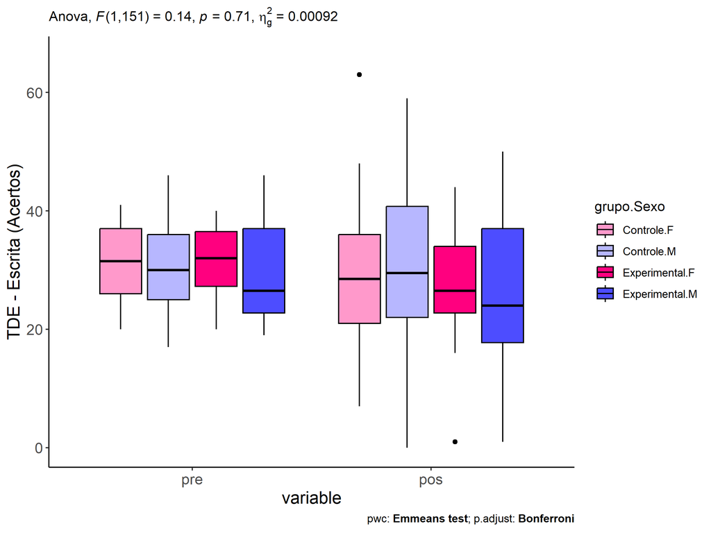

```r
plots[["grupo:Sexo"]] + ggplot2::ylab("TDE - Escrita (Acertos)") + ggplot2::scale_x_discrete(labels=c('pre', 'pos'))
```

```r
plots <- twoWayAncovaBoxPlots(
  wdat.long, "score.tde", c("grupo","Sexo"), aov, pwc.long, pre.post = "time",
  theme = "classic", color = color$prepost)
```

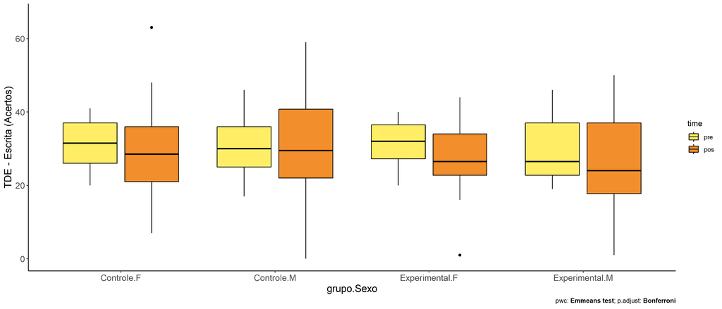

```r
plots[["grupo:Sexo"]] + ggplot2::ylab("TDE - Escrita (Acertos)")
```

### Checking linearity assumption

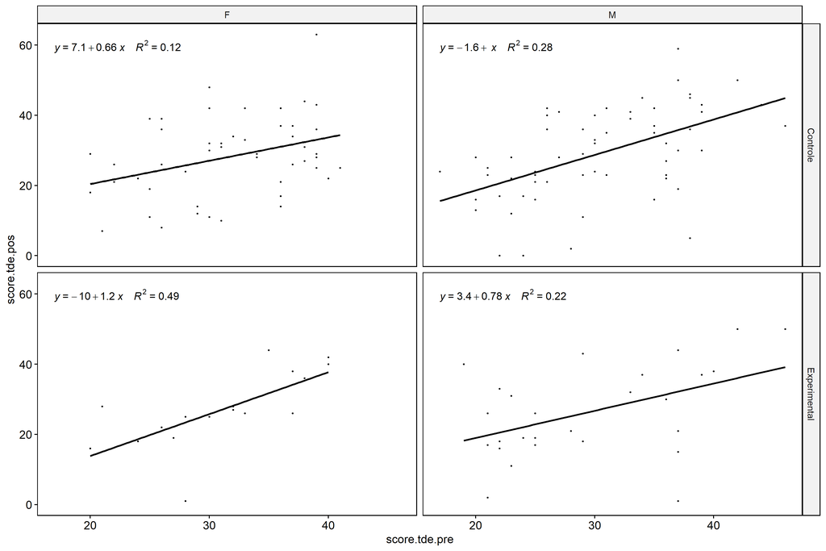

```r
ggscatter(wdat, x = "score.tde.pre", y = "score.tde.pos", size = 0.5,
          facet.by = c("grupo","Sexo"), add = "reg.line")+
  stat_regline_equation(
    aes(label =  paste(..eq.label.., ..rr.label.., sep = "~~~~"))
  )
```

### Checking normality and homogeneity

```r
res <- augment(lm(score.tde.pos ~ score.tde.pre + grupo*Sexo, data = wdat))
```

```r
shapiro_test(res$.resid)
```

```
## # A tibble: 1 × 3
##   variable   statistic p.value
##   <chr>          <dbl>   <dbl>
## 1 res$.resid     0.990   0.371
```

```r
levene_test(res, .resid ~ grupo*Sexo)
```

```
## # A tibble: 1 × 4
##     df1   df2 statistic     p
##   <int> <int>     <dbl> <dbl>
## 1     3   152      1.65 0.181
```

# ANCOVA and Pairwise for two factors **grupo:Zona**

## Without remove non-normal data

```r
pdat = remove_group_data(dat[!is.na(dat[["grupo"]]) & !is.na(dat[["Zona"]]),], "score.tde.pos", c("grupo","Zona"))

pdat.long <- rbind(pdat[,c("id","grupo","Zona")], pdat[,c("id","grupo","Zona")])
pdat.long[["time"]] <- c(rep("pre", nrow(pdat)), rep("pos", nrow(pdat)))
pdat.long[["time"]] <- factor(pdat.long[["time"]], c("pre","pos"))
pdat.long[["score.tde"]] <- c(pdat[["score.tde.pre"]], pdat[["score.tde.pos"]])

aov = anova_test(pdat, score.tde.pos ~ score.tde.pre + grupo*Zona)
laov[["grupo:Zona"]] <- get_anova_table(aov)
```

```r
pwcs <- list()
pwcs[["Zona"]] <- emmeans_test(
  group_by(pdat, grupo), score.tde.pos ~ Zona,
  covariate = score.tde.pre, p.adjust.method = "bonferroni")
pwcs[["grupo"]] <- emmeans_test(
  group_by(pdat, Zona), score.tde.pos ~ grupo,
  covariate = score.tde.pre, p.adjust.method = "bonferroni")

pwc <- plyr::rbind.fill(pwcs[["grupo"]], pwcs[["Zona"]])
pwc <- pwc[,c("grupo","Zona", colnames(pwc)[!colnames(pwc) %in% c("grupo","Zona")])]
```

```r
pwc.long <- emmeans_test(dplyr::group_by_at(pdat.long, c("grupo","Zona")),
                         score.tde ~ time,
                         p.adjust.method = "bonferroni")
lpwc[["grupo:Zona"]] <- plyr::rbind.fill(pwc, pwc.long)
```

```r
ds <- get.descriptives(pdat, "score.tde.pos", c("grupo","Zona"), covar = "score.tde.pre")
ds <- merge(ds[ds$variable != "score.tde.pre",],
            ds[ds$variable == "score.tde.pre", !colnames(ds) %in% c("variable")],
            by = c("grupo","Zona"), all.x = T, suffixes = c("", ".score.tde.pre"))
ds <- merge(get_emmeans(pwcs[["grupo"]]), ds, by = c("grupo","Zona"), suffixes = c(".emms", ""))
ds <- ds[,c("grupo","Zona","n","mean.score.tde.pre","se.score.tde.pre","mean","se","emmean","se.emms")]

colnames(ds) <- c("grupo","Zona", "N", paste0(c("M","SE")," (pre)"),
                  paste0(c("M","SE"), " (unadj)"), paste0(c("M", "SE"), " (adj)"))

lemms[["grupo:Zona"]] <- ds
```

## Computing ANCOVA and PairWise After removing non-normal data (OK)

```r
wdat = pdat

res = residuals(lm(score.tde.pos ~ score.tde.pre + grupo*Zona, data = wdat))
non.normal = getNonNormal(res, wdat$id, plimit = 0.05)

wdat = wdat[!wdat$id %in% non.normal,]

wdat.long <- rbind(wdat[,c("id","grupo","Zona")], wdat[,c("id","grupo","Zona")])
wdat.long[["time"]] <- c(rep("pre", nrow(wdat)), rep("pos", nrow(wdat)))
wdat.long[["time"]] <- factor(wdat.long[["time"]], c("pre","pos"))
wdat.long[["score.tde"]] <- c(wdat[["score.tde.pre"]], wdat[["score.tde.pos"]])


ldat[["grupo:Zona"]] = wdat

(non.normal)
```

```r
aov = anova_test(wdat, score.tde.pos ~ score.tde.pre + grupo*Zona)
laov[["grupo:Zona"]] <- merge(get_anova_table(aov), laov[["grupo:Zona"]], by="Effect", suffixes = c("","'"))

(df = get_anova_table(aov))
```

```
## ANOVA Table (type II tests)
##
##          Effect DFn DFd      F        p p<.05      ges
## 1 score.tde.pre   1 108 36.328 2.36e-08     * 2.52e-01
## 2         grupo   1 108  0.026 8.72e-01       2.42e-04
## 3          Zona   1 108  0.001 9.71e-01       1.23e-05
## 4    grupo:Zona   1 108  1.557 2.15e-01       1.40e-02
```

| Effect | DFn | DFd | F | p | p<.05 | ges |
| --- | --- | --- | --- | --- | --- | --- |
| score.tde.pre | 1 | 108 | 36.328 | 0.000 | * | 0.252 |
| grupo | 1 | 108 | 0.026 | 0.872 |  | 0.000 |
| Zona | 1 | 108 | 0.001 | 0.971 |  | 0.000 |
| grupo:Zona | 1 | 108 | 1.557 | 0.215 |  | 0.014 |

```r
pwcs <- list()
pwcs[["Zona"]] <- emmeans_test(
  group_by(wdat, grupo), score.tde.pos ~ Zona,
  covariate = score.tde.pre, p.adjust.method = "bonferroni")
pwcs[["grupo"]] <- emmeans_test(
  group_by(wdat, Zona), score.tde.pos ~ grupo,
  covariate = score.tde.pre, p.adjust.method = "bonferroni")

pwc <- plyr::rbind.fill(pwcs[["grupo"]], pwcs[["Zona"]])
pwc <- pwc[,c("grupo","Zona", colnames(pwc)[!colnames(pwc) %in% c("grupo","Zona")])]
```

| grupo | Zona | term | .y. | group1 | group2 | df | statistic | p | p.adj | p.adj.signif |
| --- | --- | --- | --- | --- | --- | --- | --- | --- | --- | --- |
|  | Rural | score.tde.pre*grupo | score.tde.pos | Controle | Experimental | 108 | -0.619 | 0.537 | 0.537 | ns |
|  | Urbana | score.tde.pre*grupo | score.tde.pos | Controle | Experimental | 108 | 1.096 | 0.276 | 0.276 | ns |
| Controle |  | score.tde.pre*Zona | score.tde.pos | Rural | Urbana | 108 | -0.670 | 0.504 | 0.504 | ns |
| Experimental |  | score.tde.pre*Zona | score.tde.pos | Rural | Urbana | 108 | 1.053 | 0.295 | 0.295 | ns |

```r
pwc.long <- emmeans_test(dplyr::group_by_at(wdat.long, c("grupo","Zona")),
                         score.tde ~ time,
                         p.adjust.method = "bonferroni")
lpwc[["grupo:Zona"]] <- merge(plyr::rbind.fill(pwc, pwc.long), lpwc[["grupo:Zona"]], by=c("grupo","Zona","term",".y.","group1","group2"), suffixes = c("","'"))
```

| grupo | Zona | term | .y. | group1 | group2 | df | statistic | p | p.adj | p.adj.signif |
| --- | --- | --- | --- | --- | --- | --- | --- | --- | --- | --- |
| Controle | Rural | time | score.tde | pre | pos | 218 | 1.929 | 0.055 | 0.055 | ns |
| Controle | Urbana | time | score.tde | pre | pos | 218 | 0.157 | 0.876 | 0.876 | ns |
| Experimental | Rural | time | score.tde | pre | pos | 218 | 0.654 | 0.514 | 0.514 | ns |
| Experimental | Urbana | time | score.tde | pre | pos | 218 | 1.096 | 0.274 | 0.274 | ns |

```r
ds <- get.descriptives(wdat, "score.tde.pos", c("grupo","Zona"), covar = "score.tde.pre")
ds <- merge(ds[ds$variable != "score.tde.pre",],
            ds[ds$variable == "score.tde.pre", !colnames(ds) %in% c("variable")],
            by = c("grupo","Zona"), all.x = T, suffixes = c("", ".score.tde.pre"))
ds <- merge(get_emmeans(pwcs[["grupo"]]), ds, by = c("grupo","Zona"), suffixes = c(".emms", ""))
ds <- ds[,c("grupo","Zona","n","mean.score.tde.pre","se.score.tde.pre","mean","se","emmean","se.emms")]

colnames(ds) <- c("grupo","Zona", "N", paste0(c("M","SE")," (pre)"),
                  paste0(c("M","SE"), " (unadj)"), paste0(c("M", "SE"), " (adj)"))

lemms[["grupo:Zona"]] <- merge(ds, lemms[["grupo:Zona"]], by=c("grupo","Zona"), suffixes = c("","'"))
```

| grupo | Zona | N | M (pre) | SE (pre) | M (unadj) | SE (unadj) | M (adj) | SE (adj) |
| --- | --- | --- | --- | --- | --- | --- | --- | --- |
| Controle | Rural | 66 | 31.212 | 0.847 | 28.015 | 1.456 | 27.401 | 1.240 |
| Controle | Urbana | 11 | 29.000 | 1.489 | 28.364 | 3.007 | 29.600 | 3.033 |
| Experimental | Rural | 31 | 29.645 | 1.361 | 28.065 | 2.002 | 28.761 | 1.806 |
| Experimental | Urbana | 5 | 29.200 | 3.056 | 22.600 | 5.997 | 23.669 | 4.492 |

### Plots for ancova

```r
plots <- twoWayAncovaPlots(
  wdat, "score.tde.pos", c("grupo","Zona"), aov, pwcs, addParam = c("mean_se"),
  font.label.size=10, step.increase=0.05, p.label="p.adj",
  subtitle = which(aov$Effect == "grupo:Zona"))
```

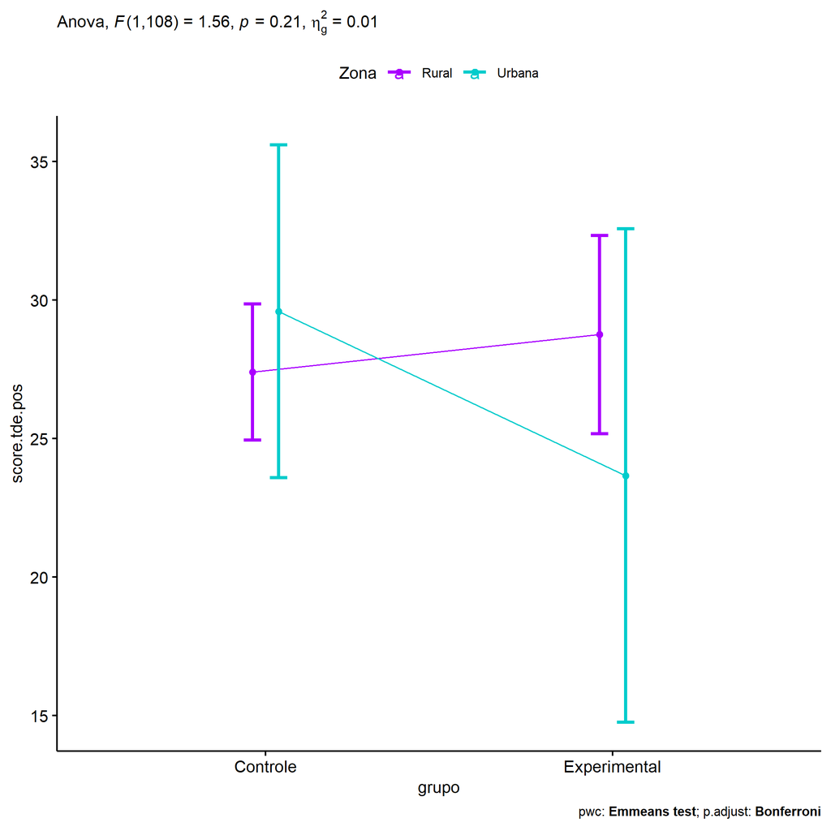

```r
if (!is.null(plots[["grupo"]]))
  plots[["grupo"]] + ggplot2::scale_color_manual(values = color[["Zona"]])
```

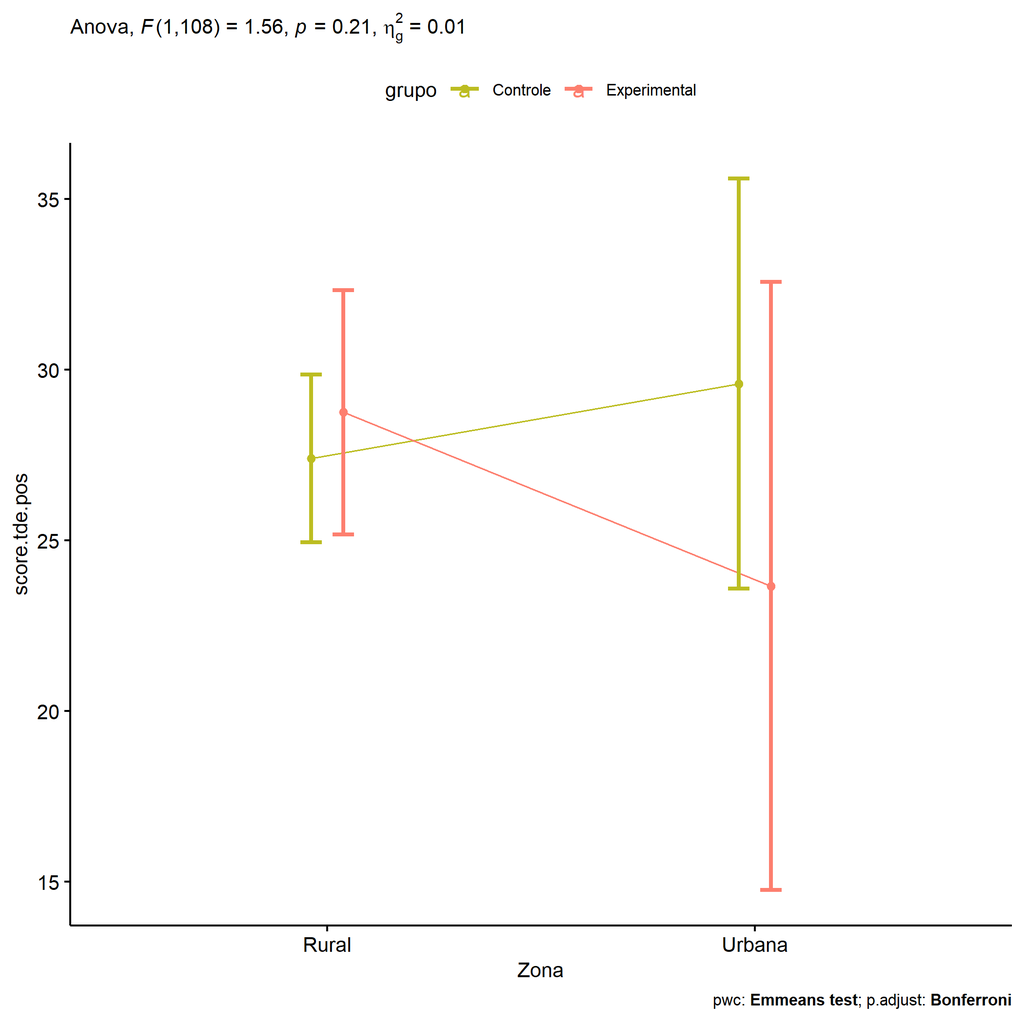

```r
if (!is.null(plots[["Zona"]]))
  plots[["Zona"]] + ggplot2::scale_color_manual(values = color[["grupo"]])
```

```r
plots <- twoWayAncovaBoxPlots(
  wdat, "score.tde.pos", c("grupo","Zona"), aov, pwcs, covar = "score.tde.pre",
  theme = "classic", color = color[["grupo:Zona"]],
  subtitle = which(aov$Effect == "grupo:Zona"))
```

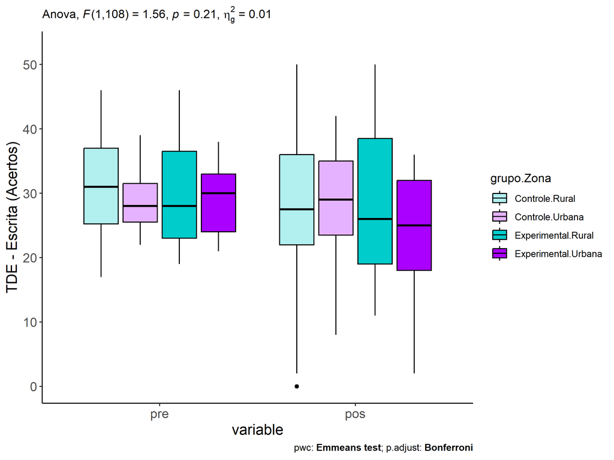

```r
plots[["grupo:Zona"]] + ggplot2::ylab("TDE - Escrita (Acertos)") + ggplot2::scale_x_discrete(labels=c('pre', 'pos'))
```

```r
plots <- twoWayAncovaBoxPlots(
  wdat.long, "score.tde", c("grupo","Zona"), aov, pwc.long, pre.post = "time",
  theme = "classic", color = color$prepost)
```

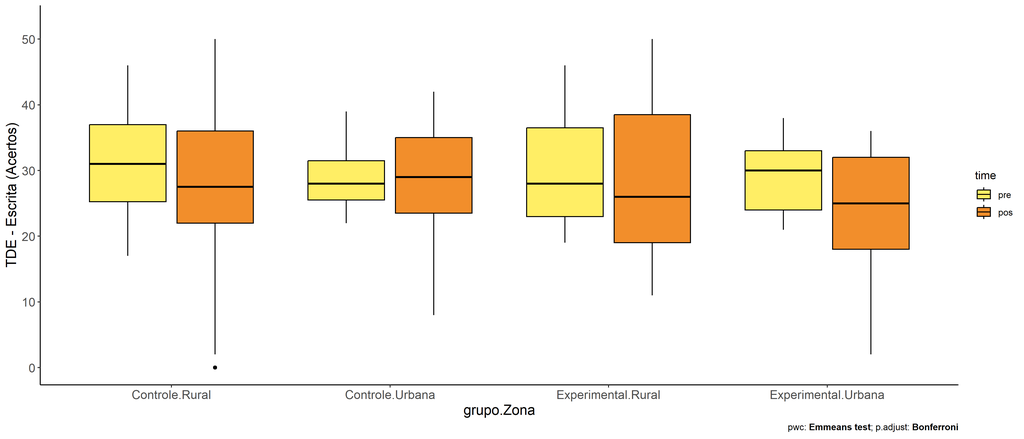

```r
plots[["grupo:Zona"]] + ggplot2::ylab("TDE - Escrita (Acertos)")
```

### Checking linearity assumption

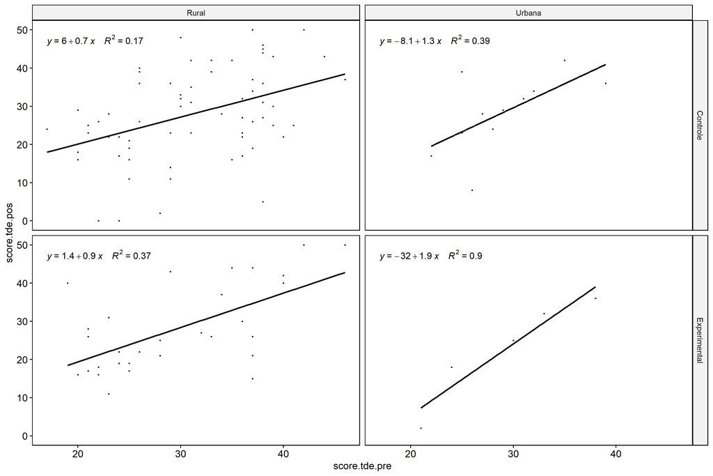

```r
ggscatter(wdat, x = "score.tde.pre", y = "score.tde.pos", size = 0.5,
          facet.by = c("grupo","Zona"), add = "reg.line")+
  stat_regline_equation(
    aes(label =  paste(..eq.label.., ..rr.label.., sep = "~~~~"))
  )
```

### Checking normality and homogeneity

```r
res <- augment(lm(score.tde.pos ~ score.tde.pre + grupo*Zona, data = wdat))
```

```r
shapiro_test(res$.resid)
```

```
## # A tibble: 1 × 3
##   variable   statistic p.value
##   <chr>          <dbl>   <dbl>
## 1 res$.resid     0.989   0.458
```

```r
levene_test(res, .resid ~ grupo*Zona)
```

```
## # A tibble: 1 × 4
##     df1   df2 statistic     p
##   <int> <int>     <dbl> <dbl>
## 1     3   109      1.68 0.176
```

# ANCOVA and Pairwise for two factors **grupo:Cor.Raca**

## Without remove non-normal data

```r
pdat = remove_group_data(dat[!is.na(dat[["grupo"]]) & !is.na(dat[["Cor.Raca"]]),], "score.tde.pos", c("grupo","Cor.Raca"))
pdat.long <- rbind(pdat[,c("id","grupo","Cor.Raca")], pdat[,c("id","grupo","Cor.Raca")])
pdat.long[["time"]] <- c(rep("pre", nrow(pdat)), rep("pos", nrow(pdat)))
pdat.long[["time"]] <- factor(pdat.long[["time"]], c("pre","pos"))
pdat.long[["score.tde"]] <- c(pdat[["score.tde.pre"]], pdat[["score.tde.pos"]])

aov = anova_test(pdat, score.tde.pos ~ score.tde.pre + grupo*Cor.Raca)
laov[["grupo:Cor.Raca"]] <- get_anova_table(aov)
```

```r
pwcs <- list()
pwcs[["Cor.Raca"]] <- emmeans_test(
  group_by(pdat, grupo), score.tde.pos ~ Cor.Raca,
  covariate = score.tde.pre, p.adjust.method = "bonferroni")
pwcs[["grupo"]] <- emmeans_test(
  group_by(pdat, Cor.Raca), score.tde.pos ~ grupo,
  covariate = score.tde.pre, p.adjust.method = "bonferroni")

pwc <- plyr::rbind.fill(pwcs[["grupo"]], pwcs[["Cor.Raca"]])
pwc <- pwc[,c("grupo","Cor.Raca", colnames(pwc)[!colnames(pwc) %in% c("grupo","Cor.Raca")])]
```

```r
pwc.long <- emmeans_test(dplyr::group_by_at(pdat.long, c("grupo","Cor.Raca")),
                         score.tde ~ time,
                         p.adjust.method = "bonferroni")
lpwc[["grupo:Cor.Raca"]] <- plyr::rbind.fill(pwc, pwc.long)
```

```r
ds <- get.descriptives(pdat, "score.tde.pos", c("grupo","Cor.Raca"), covar = "score.tde.pre")
ds <- merge(ds[ds$variable != "score.tde.pre",],
            ds[ds$variable == "score.tde.pre", !colnames(ds) %in% c("variable")],
            by = c("grupo","Cor.Raca"), all.x = T, suffixes = c("", ".score.tde.pre"))
ds <- merge(get_emmeans(pwcs[["grupo"]]), ds, by = c("grupo","Cor.Raca"), suffixes = c(".emms", ""))
ds <- ds[,c("grupo","Cor.Raca","n","mean.score.tde.pre","se.score.tde.pre","mean","se","emmean","se.emms")]

colnames(ds) <- c("grupo","Cor.Raca", "N", paste0(c("M","SE")," (pre)"),
                  paste0(c("M","SE"), " (unadj)"), paste0(c("M", "SE"), " (adj)"))

lemms[["grupo:Cor.Raca"]] <- ds
```

## Computing ANCOVA and PairWise After removing non-normal data (OK)

```r
wdat = pdat

res = residuals(lm(score.tde.pos ~ score.tde.pre + grupo*Cor.Raca, data = wdat))
non.normal = getNonNormal(res, wdat$id, plimit = 0.05)

wdat = wdat[!wdat$id %in% non.normal,]

wdat.long <- rbind(wdat[,c("id","grupo","Cor.Raca")], wdat[,c("id","grupo","Cor.Raca")])
wdat.long[["time"]] <- c(rep("pre", nrow(wdat)), rep("pos", nrow(wdat)))
wdat.long[["time"]] <- factor(wdat.long[["time"]], c("pre","pos"))
wdat.long[["score.tde"]] <- c(wdat[["score.tde.pre"]], wdat[["score.tde.pos"]])


ldat[["grupo:Cor.Raca"]] = wdat

(non.normal)
```

```r
aov = anova_test(wdat, score.tde.pos ~ score.tde.pre + grupo*Cor.Raca)
laov[["grupo:Cor.Raca"]] <- merge(get_anova_table(aov), laov[["grupo:Cor.Raca"]], by="Effect", suffixes = c("","'"))

(df = get_anova_table(aov))
```

```
## ANOVA Table (type II tests)
##
##           Effect DFn DFd      F        p p<.05      ges
## 1  score.tde.pre   1  85 26.886 1.44e-06     * 0.240000
## 2          grupo   1  85  0.048 8.27e-01       0.000567
## 3       Cor.Raca   2  85  2.492 8.90e-02       0.055000
## 4 grupo:Cor.Raca   1  85  0.855 3.58e-01       0.010000
```

| Effect | DFn | DFd | F | p | p<.05 | ges |
| --- | --- | --- | --- | --- | --- | --- |
| score.tde.pre | 1 | 85 | 26.886 | 0.000 | * | 0.240 |
| grupo | 1 | 85 | 0.048 | 0.827 |  | 0.001 |
| Cor.Raca | 2 | 85 | 2.492 | 0.089 |  | 0.055 |
| grupo:Cor.Raca | 1 | 85 | 0.855 | 0.358 |  | 0.010 |

```r
pwcs <- list()
pwcs[["Cor.Raca"]] <- emmeans_test(
  group_by(wdat, grupo), score.tde.pos ~ Cor.Raca,
  covariate = score.tde.pre, p.adjust.method = "bonferroni")
pwcs[["grupo"]] <- emmeans_test(
  group_by(wdat, Cor.Raca), score.tde.pos ~ grupo,
  covariate = score.tde.pre, p.adjust.method = "bonferroni")

pwc <- plyr::rbind.fill(pwcs[["grupo"]], pwcs[["Cor.Raca"]])
pwc <- pwc[,c("grupo","Cor.Raca", colnames(pwc)[!colnames(pwc) %in% c("grupo","Cor.Raca")])]
```

| grupo | Cor.Raca | term | .y. | group1 | group2 | df | statistic | p | p.adj | p.adj.signif |
| --- | --- | --- | --- | --- | --- | --- | --- | --- | --- | --- |
|  | Branca | score.tde.pre*grupo | score.tde.pos | Controle | Experimental | 85 | 0.714 | 0.477 | 0.477 | ns |
|  | Indígena | score.tde.pre*grupo | score.tde.pos | Controle | Experimental |  |  |  |  |  |
|  | Parda | score.tde.pre*grupo | score.tde.pos | Controle | Experimental | 85 | -0.638 | 0.525 | 0.525 | ns |
| Controle |  | score.tde.pre*Cor.Raca | score.tde.pos | Branca | Indígena |  |  |  |  |  |
| Controle |  | score.tde.pre*Cor.Raca | score.tde.pos | Branca | Parda | 85 | 2.359 | 0.021 | 0.021 | * |
| Controle |  | score.tde.pre*Cor.Raca | score.tde.pos | Indígena | Parda |  |  |  |  |  |
| Experimental |  | score.tde.pre*Cor.Raca | score.tde.pos | Branca | Indígena | 85 | 0.007 | 0.995 | 1.000 | ns |
| Experimental |  | score.tde.pre*Cor.Raca | score.tde.pos | Branca | Parda | 85 | 0.415 | 0.679 | 1.000 | ns |
| Experimental |  | score.tde.pre*Cor.Raca | score.tde.pos | Indígena | Parda | 85 | 0.497 | 0.621 | 1.000 | ns |

```r
pwc.long <- emmeans_test(dplyr::group_by_at(wdat.long, c("grupo","Cor.Raca")),
                         score.tde ~ time,
                         p.adjust.method = "bonferroni")
lpwc[["grupo:Cor.Raca"]] <- merge(plyr::rbind.fill(pwc, pwc.long), lpwc[["grupo:Cor.Raca"]], by=c("grupo","Cor.Raca","term",".y.","group1","group2"), suffixes = c("","'"))
```

| grupo | Cor.Raca | term | .y. | group1 | group2 | df | statistic | p | p.adj | p.adj.signif |
| --- | --- | --- | --- | --- | --- | --- | --- | --- | --- | --- |
| Controle | Branca | time | score.tde | pre | pos | 172 | -0.713 | 0.477 | 0.477 | ns |
| Controle | Indígena | time | score.tde | pre | pos |  |  |  |  |  |
| Controle | Parda | time | score.tde | pre | pos | 172 | 2.605 | 0.010 | 0.010 | ** |
| Experimental | Branca | time | score.tde | pre | pos | 172 | 0.224 | 0.823 | 0.823 | ns |
| Experimental | Indígena | time | score.tde | pre | pos | 172 | 0.152 | 0.879 | 0.879 | ns |
| Experimental | Parda | time | score.tde | pre | pos | 172 | 0.765 | 0.445 | 0.445 | ns |

```r
ds <- get.descriptives(wdat, "score.tde.pos", c("grupo","Cor.Raca"), covar = "score.tde.pre")
ds <- merge(ds[ds$variable != "score.tde.pre",],
            ds[ds$variable == "score.tde.pre", !colnames(ds) %in% c("variable")],
            by = c("grupo","Cor.Raca"), all.x = T, suffixes = c("", ".score.tde.pre"))
ds <- merge(get_emmeans(pwcs[["grupo"]]), ds, by = c("grupo","Cor.Raca"), suffixes = c(".emms", ""))
ds <- ds[,c("grupo","Cor.Raca","n","mean.score.tde.pre","se.score.tde.pre","mean","se","emmean","se.emms")]

colnames(ds) <- c("grupo","Cor.Raca", "N", paste0(c("M","SE")," (pre)"),
                  paste0(c("M","SE"), " (unadj)"), paste0(c("M", "SE"), " (adj)"))

lemms[["grupo:Cor.Raca"]] <- merge(ds, lemms[["grupo:Cor.Raca"]], by=c("grupo","Cor.Raca"), suffixes = c("","'"))
```

| grupo | Cor.Raca | N | M (pre) | SE (pre) | M (unadj) | SE (unadj) | M (adj) | SE (adj) |
| --- | --- | --- | --- | --- | --- | --- | --- | --- |
| Controle | Branca | 11 | 33.000 | 2.370 | 36.000 | 3.477 | 33.923 | 3.235 |
| Controle | Parda | 50 | 31.060 | 0.907 | 25.920 | 1.715 | 25.525 | 1.508 |
| Experimental | Branca | 5 | 35.200 | 4.067 | 33.800 | 8.345 | 29.815 | 4.823 |
| Experimental | Indígena | 8 | 30.000 | 2.970 | 29.250 | 4.199 | 29.774 | 3.766 |
| Experimental | Parda | 17 | 26.647 | 1.480 | 24.059 | 2.547 | 27.490 | 2.666 |